# Machine Learning Pipeline

In this notebook, we are going to build a pipeline for a general prediction problem.

```python
# Standard Imports
from src.utils import *
from src.get_feature_names import get_feature_names
```

```python
# Set inline graphs
sns.set()
%matplotlib inline
```

## Introduction

We suppose the data consists in 3 files:

- *X_train.csv*
- *y_train.csv*
- *X_test.csv*

This is the standard format for prediction tasks.

We need to produce a *y_test.csv* file, with the predicted values corresponding to the *X_test.csv* covariates.

The functions we will write are going to be general and will adapt to any type of dataset, and we will test them on the [House Prices Dataset](https://www.kaggle.com/c/house-prices-advanced-regression-techniques) which is a standard dataset for these kind of tasks.

First, we import the data.

```python
# Import data
house_dataset = pd.read_csv("data/house_prices.csv")
```

```python
# Insert missing values
np.random.seed(1)
n_rows, n_cols = np.shape(house_dataset)
n_drop = int(np.floor(n_rows/10))
for col in range(1, n_cols):
    rows_todrop = np.random.choice(n_rows, n_drop, replace=False)
    #house_dataset.iloc[rows_todrop, col] = np.nan
```

```python
# Save dataset
house_dataset.to_csv("data/house_dataset_ml.csv", index=False)
```

```python
# Drop Name
house_dataset.drop(["Id"], axis=1, inplace=True)
```

```python
# Covariates
X = house_dataset.iloc[:,:-1]
X.head()
```

|  | MSSubClass | MSZoning | LotFrontage | LotArea | Street | Alley | LotShape | LandContour | Utilities | LotConfig | ... | ScreenPorch | PoolArea | PoolQC | Fence | MiscFeature | MiscVal | MoSold | YrSold | SaleType | SaleCondition |
| --- | --- | --- | --- | --- | --- | --- | --- | --- | --- | --- | --- | --- | --- | --- | --- | --- | --- | --- | --- | --- | --- |
| 0 | 60 | RL | 65.0 | 8450 | Pave | NaN | Reg | Lvl | AllPub | Inside | ... | 0 | 0 | NaN | NaN | NaN | 0 | 2 | 2008 | WD | Normal |
| 1 | 20 | RL | 80.0 | 9600 | Pave | NaN | Reg | Lvl | AllPub | FR2 | ... | 0 | 0 | NaN | NaN | NaN | 0 | 5 | 2007 | WD | Normal |
| 2 | 60 | RL | 68.0 | 11250 | Pave | NaN | IR1 | Lvl | AllPub | Inside | ... | 0 | 0 | NaN | NaN | NaN | 0 | 9 | 2008 | WD | Normal |
| 3 | 70 | RL | 60.0 | 9550 | Pave | NaN | IR1 | Lvl | AllPub | Corner | ... | 0 | 0 | NaN | NaN | NaN | 0 | 2 | 2006 | WD | Abnorml |
| 4 | 60 | RL | 84.0 | 14260 | Pave | NaN | IR1 | Lvl | AllPub | FR2 | ... | 0 | 0 | NaN | NaN | NaN | 0 | 12 | 2008 | WD | Normal |

5 rows × 79 columns

```python
# Target
y = house_dataset.iloc[:,-1]
y.head()
```

```
0    208500
1    181500
2    223500
3    140000
4    250000
Name: SalePrice, dtype: int64
```

We split the data into a training sample with 80% of the observations and a test sample with 20% of the observations.

```python
# Split data
X_train, X_test, y_train, y_test = train_test_split(X, y, test_size=0.2)
```

Now we are ready to build and test our pipeline.

## Import and Explore Data

The first thing that we want to do is some data exploration.

First, we identify categorical and numerical variables.

```python
# Save column types
numerical_cols = list(X_train.describe().columns)
categorical_cols = list(X_train.describe(include=object).columns)
print("There are %i numerical and %i categorical variables" % (len(numerical_cols), len(categorical_cols)))
```

```
There are 36 numerical and 43 categorical variables
```

Let's start by analyzing the numerical variables.

```python
X_numerical = X_train.loc[:, numerical_cols]
corr = X_numerical.corr()
```

[figure not shown]

```python
fig, ax = plt.subplots(1, 1, figsize=(10,10))
fig.suptitle("Correlation between categorical variables", fontsize=16)
cbar_ax = fig.add_axes([.95, .12, .05, .76])
sns.heatmap(corr, vmin=-1, vmax=1, center=0, cmap=sns.diverging_palette(20, 220, n=20),
            square=True, ax=ax, cbar_ax = cbar_ax)
plt.show()
```

For the non/numeric columns, we need a further option.

```python
unique_values = X_train.describe(include=object).T.unique
```

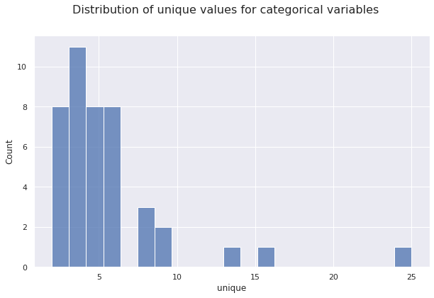

```python
# Plot
fig, ax = plt.subplots(1, 1, figsize=(10,6))
fig.suptitle("Distribution of unique values for categorical variables", fontsize=16)
sns.histplot(data=unique_values)
plt.show();
```

Let's save the identity of the numerical and categorical columns.

```python
# Save column types
numerical_cols = list(X_train.describe().columns)
categorical_cols = list(X_train.describe(include=object).columns)
```

How many missing values are there in the dataset?

```python
missing_values = X_train.isnull().sum().sort_values(ascending=True)[-20:] / len(X_train)
```

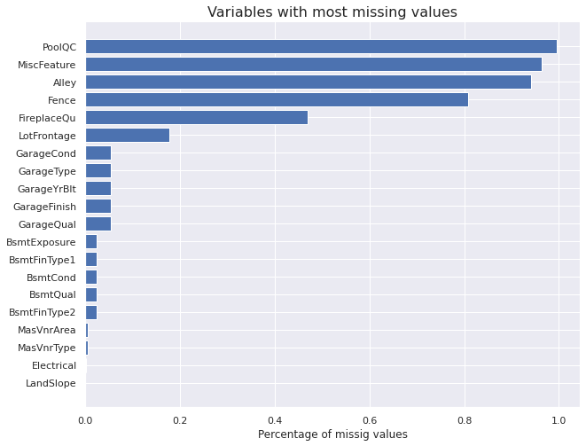

```python
fig, ax = plt.subplots(figsize=(10,8))
ax.set_title("Variables with most missing values", fontsize=16)
ax.barh(np.arange(len(missing_values)), missing_values)
ax.set_yticks(np.arange(len(missing_values)))
ax.set_yticklabels(missing_values.index)
ax.set_xlabel('Percentage of missig values')
plt.show()
```

## Pre-processing

Which imputer should to use? There are three main categories:

- Simple Imputer
- KNN Imputer
- Iterative Imputer: see comparison [here](https://scikit-learn.org/stable/auto_examples/impute/plot_iterative_imputer_variants_comparison.html)

```python
# Inputer for numerical variables
num = Pipeline(steps=[
    ('ii', IterativeImputer()),
    ('ss', StandardScaler())
    ])
```

```python
# One Hot Encoder for categorical data
cat = Pipeline(steps=[
    ('si', SimpleImputer(strategy="most_frequent")),
    ('ohe', OneHotEncoder(handle_unknown="ignore")),
    ])
```

```python
# Preprocess column transformer for preprocessing data
preprocess = ColumnTransformer(
                    transformers=[
                        ('num', num, numerical_cols),
                        ('cat', cat, categorical_cols),
                    ])
```

## Information and components

How much information is contained in our dataset? It is a dense or sparse dataset?

```python
X_clean = num.fit_transform(X_numerical)
pca = PCA().fit(X_clean)
explained_variance = pca.explained_variance_ratio_
```

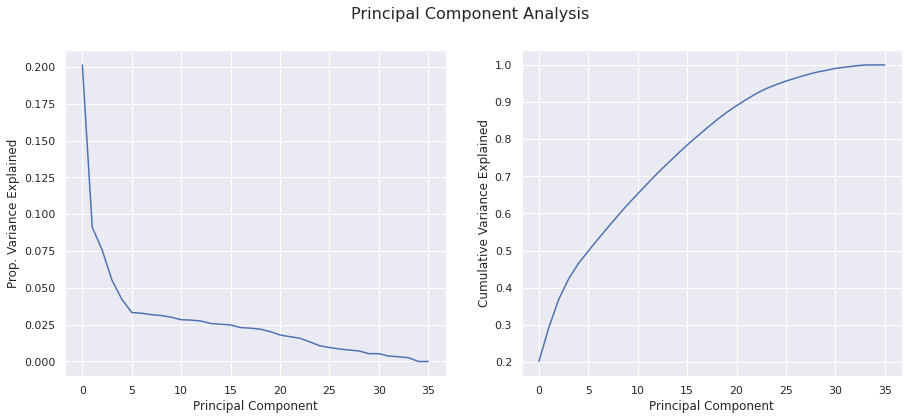

```python
fig, (ax1, ax2) = plt.subplots(1,2, figsize=(15,6))
fig.suptitle('Principal Component Analysis', fontsize=16);

# Relative
ax1.plot(range(len(explained_variance)), explained_variance)
ax1.set_ylabel('Prop. Variance Explained')
ax1.set_xlabel('Principal Component');

# Cumulative
ax2.plot(range(len(explained_variance)), np.cumsum(explained_variance))
ax2.set_ylabel('Cumulative Variance Explained');
ax2.set_xlabel('Principal Component');
```

## Feature Importance

```python
def plot_featureimportance(importance, preprocess):
    df = pd.DataFrame({"names": get_feature_names(preprocess), "values": importance})
    df = df.sort_values("values").iloc[:20, :]
    # plot
    fig, ax = plt.subplots(figsize=(10,8))
    ax.set_title("Feature importance", fontsize=16)
    sns.barplot(y="names", x="values", data=df)
    ax.barh(np.arange(len(df)), df["values"])
    plt.show()
```

```python
def featureimportance_lr(X, y):
    X_clean = preprocess.fit_transform(X)
    # fit the model
    model = LinearRegression()
    model.fit(X_clean, y)
    # get importance
    importance = np.abs(model.coef_)
    plot_featureimportance(importance, preprocess)
```

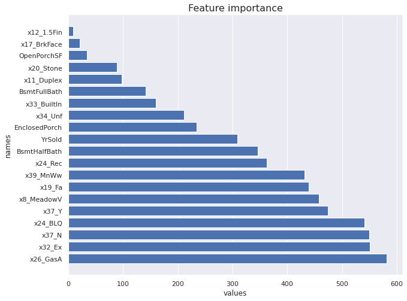

```python
# Plot linear feature importance
featureimportance_lr(X_train, y_train)
```

We now look at regression tree feature importance.

```python
def featureimportance_forest(X, y):
    X_clean = preprocess.fit_transform(X)
    # fit the model
    model = RandomForestRegressor()
    model.fit(X_clean, y)
    # get importance
    importance = model.feature_importances_
    plot_featureimportance(importance, preprocess)
```

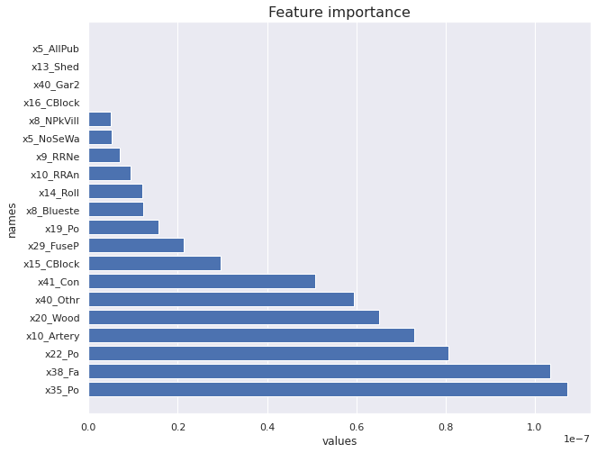

```python
# Plot tree feature importance
featureimportance_forest(X_train, y_train)
```

## Weighting

Another important check to perform concerns weighting. Is the distribution of our objective variable the same in the training and in the test sample? If it is not the case, we might get a poor performance just because our training sample is not representative of our testing sample.

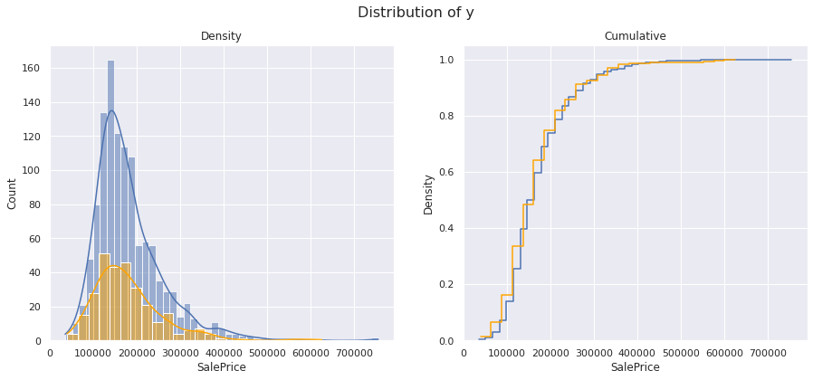

```python
fig, (ax1, ax2) = plt.subplots(1, 2, figsize=(15,6))
fig.suptitle("Distribution of y", fontsize=16)
# plot 1
sns.histplot(data=y_train, kde=True, ax=ax1)
sns.histplot(data=y_test, kde=True, ax=ax1, color='orange')
ax1.set_title("Density")
# plot 2
sns.histplot(data=y_train,  element="step", fill=False,
    cumulative=True, stat="density", common_norm=False, ax=ax2)
sns.histplot(data=y_test, element="step", fill=False,
    cumulative=True, stat="density", common_norm=False, ax=ax2, color='orange')
ax2.set_title("Cumulative");
```

Since the size of the test sample is smaller than the size of the training sample, the two densities are different. However, the cumulative distributions indicate that the standardized distributions are the same

## Model

There are many models to choose among.

```python
# prepare models
models = {"Lasso": Lasso(alpha=100),
          "Ridge": BayesianRidge(),
          "KNN": KNeighborsRegressor(),
          "Kernel": KernelRidge(),
          "Naive": GaussianNB(),
          "SVM": SVR(),
          "Ada": AdaBoostRegressor(),
          "Tree": DecisionTreeRegressor(),
          "Forest": RandomForestRegressor(),
          "GBoost": GradientBoostingRegressor(),
          "XGBoost": XGBRegressor(),
          "LGBoost": LGBMRegressor()}
```

```python
def evaluate_model(model, name, X, y, cv, scoring):
    X_clean = preprocess.fit_transform(X)
    start = time.perf_counter()
    cv_results = cross_val_score(model, X_clean, y, cv=cv, scoring=scoring)
    t = time.perf_counter()-start
    score = {"model":name, "mean":-np.mean(cv_results), "std":np.std(cv_results), "time":t}
    print("%s: %f (%f) in %f seconds" % (name, -np.mean(cv_results), np.std(cv_results), t))
    return score
```

```python
def plot_model_scores(scores):
    fig, (ax1, ax2) = plt.subplots(1, 2, figsize=(15,6))
    fig.suptitle("Comparing algorithms", fontsize=16)
    # plot 1
    scores.sort_values("mean", ascending=False, inplace=True)
    ax1.set_title('Mean squared error')
    ax1.barh(range(len(scores)), scores["mean"], xerr=scores["std"])
    ax1.set_yticks(range(len(scores)))
    ax1.set_yticklabels([s for s in scores["model"]])
    # plot 2
    scores.sort_values("time", ascending=False, inplace=True)
    ax2.set_title('Time')
    ax2.barh(range(len(scores)), scores["time"], color='tab:orange')
    ax2.set_yticks(range(len(scores)))
    ax2.set_yticklabels([s for s in scores["model"]])
    plt.show()
```

```python
def compare_models(models):
    scores = pd.DataFrame()
    cv = KFold(n_splits=5)
    scoring = 'neg_mean_squared_error'
    for name, model in models.items():
        score = evaluate_model(model, name, X_test, y_test, cv, scoring)
        scores = scores.append(score, ignore_index=True)
    return scores
```

```python
scores = compare_models(models)
```

```
Lasso: 849934199.126629 (285152522.737521) in 0.329386 seconds
Ridge: 827924920.932078 (326353598.611473) in 0.181050 seconds
KNN: 1540875095.033062 (900551846.663163) in 0.020844 seconds
Kernel: 1076743447.688732 (282369130.234153) in 0.035972 seconds
Naive: 3944281477.860841 (1134929802.343922) in 0.104809 seconds
SVM: 6867067195.465123 (2464875421.748582) in 0.061193 seconds
Ada: 1411246179.098435 (705916972.643676) in 0.402404 seconds
Tree: 2348152536.552893 (1088856423.969833) in 0.063061 seconds
Forest: 1065563311.071501 (615079560.771947) in 1.352981 seconds
GBoost: 1007951190.925489 (502487684.493070) in 0.564701 seconds
XGBoost: 1078274344.803468 (490961427.917196) in 1.251573 seconds
LGBoost: 1234540884.218687 (409634639.630198) in 0.148777 seconds
```

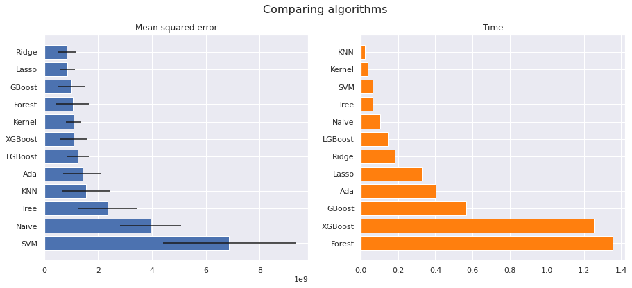

```python
plot_model_scores(scores)
```

## Pipeline

First, we want to further split the training data into training and validation set.

```python
# Build a validation set
X_train, X_validation, y_train, y_validation = train_test_split(X_train, y_train, test_size=0.2)
```

Then, we want to pick a model.

```python
# Set model
model = LGBMRegressor()
```

We need to choose a cross-validation procedure to test our model.

```python
cv = KFold()
```

Finally, we can combine all the parts into a single pipeline.

```python
final_pipeline = Pipeline(steps=[
        ('preprocess', preprocess),
        ('model', model)
        ])
```

Now we can decide which parts of the pipeline to test.

```python
# Select parameters to explore
param_grid = {'preprocess__num__ii': [SimpleImputer(), KNNImputer(), IterativeImputer()],
              'preprocess__cat__si__strategy': ["most_frequent", "constant"],
              'model__learning_rate': [0.1, 0.2],
              'model__subsample': [1.0, 0.5],
              'model__max_depth': [30, -1]}
```

We now generate a grid of parameters we want to search over.

```python
# Save pipeline
grid_search = GridSearchCV(final_pipeline,
                           param_grid,
                           cv=cv,
                           n_jobs=-1,
                           scoring='neg_mean_squared_error',
                           verbose=3)
```

We fit the pipeline and pick the best estimator, from the cross-validation score.

```python
# Fit pipeline
grid_search.fit(X_train, y_train)
grid_search.best_estimator_
```

```
Fitting 5 folds for each of 48 candidates, totalling 240 fits
```

```
Pipeline(steps=[('preprocess',
                 ColumnTransformer(transformers=[('num',
                                                  Pipeline(steps=[('ii',
                                                                   KNNImputer()),
                                                                  ('ss',
                                                                   StandardScaler())]),
                                                  ['MSSubClass', 'LotFrontage',
                                                   'LotArea', 'OverallQual',
                                                   'OverallCond', 'YearBuilt',
                                                   'YearRemodAdd', 'MasVnrArea',
                                                   'BsmtFinSF1', 'BsmtFinSF2',
                                                   'BsmtUnfSF', 'TotalBsmtSF',
                                                   '1stFlrSF', '2ndFlrSF',
                                                   'LowQualFinSF', 'GrLivArea',
                                                   'BsmtFullBat...
                                                   'LotConfig', 'LandSlope',
                                                   'Neighborhood', 'Condition1',
                                                   'Condition2', 'BldgType',
                                                   'HouseStyle', 'RoofStyle',
                                                   'RoofMatl', 'Exterior1st',
                                                   'Exterior2nd', 'MasVnrType',
                                                   'ExterQual', 'ExterCond',
                                                   'Foundation', 'BsmtQual',
                                                   'BsmtCond', 'BsmtExposure',
                                                   'BsmtFinType1',
                                                   'BsmtFinType2', 'Heating',
                                                   'HeatingQC', 'CentralAir',
                                                   'Electrical', ...])])),
                ('model', LGBMRegressor(learning_rate=0.2, max_depth=30))])
```

We have three ways of testing the quality of fit of our model:

- score on the training data
- score on the validation data
- score on the test data

**Score on the training data**: this is a biased score since we have picked the model that was best fitting the training data. Kfold cross-validation is efficient in terms of data use, but still evaluates the model over the same data it was trained.

```python
# Cross/validation score
y_train_hat = grid_search.best_estimator_.predict(X_train)
train_rmse = mean_squared_error(y_train, y_train_hat, squared=False)
print('RMSE on training data :', train_rmse)
```

```
RMSE on training data : 6191.264167897775
```

**Score on the validation data**: this is an unbiased score since we have left out this sample exactly for this purpose. However, be aware that the validation score is unbiased on on the first run. Once we change the grid and pick the algorithm based on previous validation data scores, also this score becomes biased.

```python
# Validation set score
y_validation_hat = grid_search.best_estimator_.predict(X_validation)
validation_rmse = mean_squared_error(y_validation, y_validation_hat, squared=False)
print('RMSE on validation data :', validation_rmse)
```

```
RMSE on validation data : 25988.57054314382
```

**Score on the test data**: this is the actual score. Normally we do not have access to `y_test` and therefore we cannot assess the goodness of fit of our model on the test data. We can only rely on the score from the validation data in order to estimate our score on the test data.

```python
# Actual score
y_test_hat = grid_search.best_estimator_.predict(X_test)
test_rmse = mean_squared_error(y_test, y_test_hat, squared=False)
print('RMSE on test data :', test_rmse)
```

```
RMSE on test data : 28254.21527747959
```

## Conclusion

Thanks for reading. I really hope this very simple pipeline can be of help!

More from me:

- github: https://github.com/matteocourthoud
- website: https://matteocourthoud.github.io